# APM1205 - Formative Assessment 2: Linear Models

Rachelle Erika D. Borja

### PART 1 - Understanding the Dataset

**A. Identify the variables**

- Predictor variable **X**: `TV` (TV advertising budget)
- Response variable **Y**: `Sales` (product sales)

**B. Describe the variables**

`TV` records how much a market spent on television advertising, in thousands of dollars. `Sales` records how many units of the product were sold in that market, in thousands of units. Each of the 200 rows is one market, so the dataset lets us ask whether markets that spent more on TV ads tended to also sell more product.

**C. Research question**

Can product sales be predicted from TV advertising expenditure?

### PART 2 - Exploratory Data Analysis

**A. Create a scatterplot**

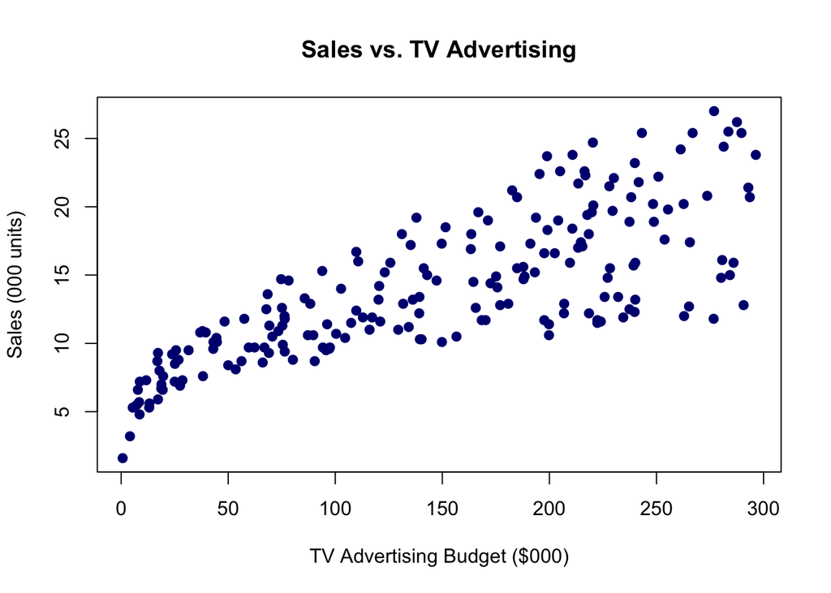

**B. Interpret the scatterplot**

The scatterplot indicates a positive relationship because markets with larger TV budgets tend to have higher sales. The trend looks roughly linear through the middle of the data. The points fan out more at higher TV spending levels, meaning the scatter around the trend grows a bit as TV budget increases. The strength of the relationship appears moderately strong, as the data points cluster relatively closely around an upward-trending, approximately linear path, but an amount of point-to-point scatter remains, so TV spending alone will not predict sales exactly. Even so, the pattern is consistent enough that TV advertising appears potentially useful as a predictor of sales.

### PART 3 - Simple Linear Regression Model

**A. Fit the model in R**

```
##
## Call:
## lm(formula = Sales ~ TV, data = advertising)
##
## Residuals:
##     Min      1Q  Median      3Q     Max
## -8.3860 -1.9545 -0.1913  2.0671  7.2124
##
## Coefficients:
##             Estimate Std. Error t value Pr(>|t|)
## (Intercept) 7.032594   0.457843   15.36   <2e-16 ***
## TV          0.047537   0.002691   17.67   <2e-16 ***
## ---
## Signif. codes:  0 '***' 0.001 '**' 0.01 '*' 0.05 '.' 0.1 ' ' 1
##
## Residual standard error: 3.259 on 198 degrees of freedom
## Multiple R-squared:  0.6119, Adjusted R-squared:  0.6099
## F-statistic: 312.1 on 1 and 198 DF,  p-value: < 2.2e-16
```

**B. Report the coefficients**

```
## (Intercept)          TV
##  7.03259355  0.04753664
```

The intercept is **A = 7.0326** and the slope is **B = 0.0475**.

**C. Write the regression equation**

The fitted equation format is $\hat{Y} = A + BX$.

**Sales = 7.0326 + 0.0475(TV)**

**D. Interpret the slope**

On average, holding all else in the data-generating process constant for every additional $1,000 spent on TV advertising, predicted sales increase by approximately **0.0475 thousand units**s (about 47.5 units). The intercept of 7.0326 represents predicted sales when TV spending is $0, but this is primarily a mathematical anchor for the line rather than a meaningful real-world scenario, as no market in the dataset spends nothing on television.

### PART 4 - Least-Squares and Residual Analysis

**A. Obtain fitted values and residuals**

The least-squares method chooses $A$ and $B$ so that $\sum E_i^2$ (the sum of squared residuals) is as small as possible — it is the line that minimizes total squared vertical distance between the observed points and the fitted line, which is why it is the “best-fitting” line in this sense rather than any other criterion (like minimizing absolute error).

**B. Show the first 10 observations**

```
##       TV Sales Predicted_Sales   Residual
## 1  230.1  22.1       17.970775  4.1292255
## 2   44.5  10.4        9.147974  1.2520260
## 3   17.2   9.3        7.850224  1.4497762
## 4  151.5  18.5       14.234395  4.2656054
## 5  180.8  12.9       15.627218 -2.7272181
## 6    8.7   7.2        7.446162 -0.2461623
## 7   57.5  11.8        9.765950  2.0340496
## 8  120.2  13.2       12.746498  0.4535023
## 9    8.6   4.8        7.441409 -2.6414087
## 10 199.8  10.6       16.530414 -5.9304143
```

**C. Interpret one residual**

Based on observation 1, where `TV` = 230.1 and actual `Sales` = 22.1. The model predicts $\widehat{Sales} = 7.0326 + 0.0475(230.1) \approx 17.97$ thousand units, but the market actually sold 22.1 thousand units. The residual is $22.1 - 17.97 = 4.13$, meaning this market sold about 4,130 more units than the model predicted for that level of TV spending; actual sales outperformed what TV advertising alone would suggest, likely because of other factors (such as radio or newspaper spending, or market-specific conditions) that the simple model does not capture.

### PART 5 - Residual Plot

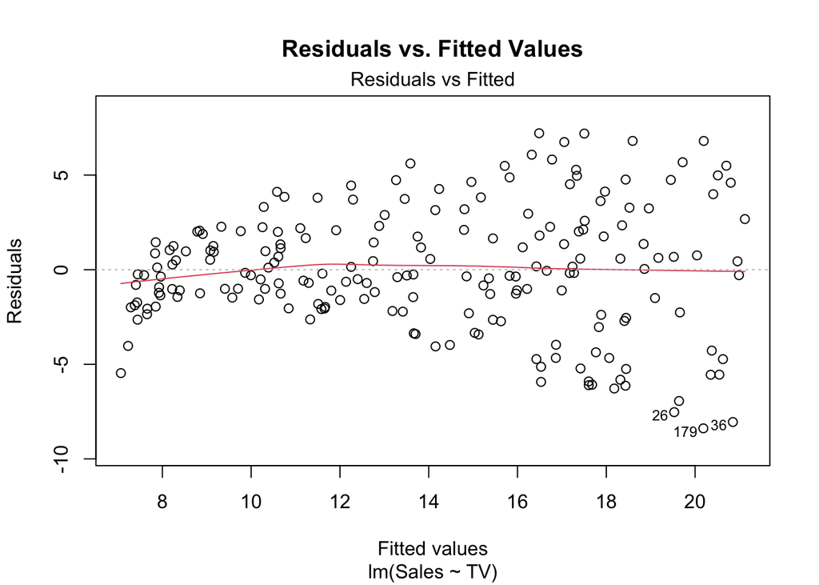

### PART 6 - Residual Standard Error

```
## [1] 3.258656
```

**Interpretation:**

The residual standard error is **$S_e \approx 3.259$**. This means that, on average, the model’s predicted Sales differ from actual Sales by about 3.26 thousand units (roughly 3,259 units). Given that Sales in the dataset range from about 1.6 to 27.0 thousand units, an average error of ~3.26 thousand units is moderate which are useful for spotting broad trends, but not precise enough to rely on for exact sales forecasts in a single market.

### PART 7 - Sums of Squares

```
## [1] 0.6118751
```

```
##       Measure    Value
## 1         TSS 5417.149
## 2         RSS 2102.531
## 3       RegSS 3314.618
## 4 RegSS + RSS 5417.149
```

As verified by the output table above, $TSS \approx RegSS + RSS$ (5417.149 = 3314.618 + 2102.531).

### PART 8 - Correlation and r-squared

```
##          r  r_squared summary_r2
##  0.7822244  0.6118751  0.6118751
```

**Interpretation:**

The correlation coefficient is **r ≈ 0.7822**, and the coefficient of determination is **r² ≈ 0.6119**. The positive sign of $r$ confirms that TV spending and Sales move in the same direction, as one increases, so does the other. A value of 0.78 indicates a moderately strong to strong positive linear association. The r² value tells us that about **61.2%** of the variation in Sales across markets is explained by TV advertising expenditure alone, leaving roughly 38.8% of the variation attributable to other factors (radio, newspaper spending, or unmeasured market differences) or to inherent randomness.

### PART 9 - Overall Conclusion

Overall the evidence shows a moderate positive linear link between TV advertising expenditure and product sales. From this analysis, product sales can be predicted from TV advertising expenditure. The scatterplot shows a roughly linear trend, and the fitted regression equation $\widehat{Sales} = 7.0326 + 0.0475(TV)$ tells us that for every additional $1,000 spent on TV ads, product sales rise by about 47.5 units on average. TV advertising expenditure alone explains about 61% of the variation in product sales across the 200 markets given the correlation $r \approx 0.78$ and $r^2 \approx 0.612$. This is significant for a single predictor but still leaves a big part of the variation unexplained. The residual standard error of 3.26 thousand units shows that individual predictions have real uncertainty, and the residual plot shows a mild fan‑shaped pattern instead of perfect random scatter, meaning the straight‑line model is reasonable but not perfect. Taken together, TV advertising expenditure can be used to predict product sales in a sense; higher TV advertising expenditure means higher product sales, but it is not enough alone for precise market‑level forecasts, and adding other predictors, like radio, would likely improve predictive accuracy.